# Vowel Acoustics as Predictors of Speech Intelligibility in Dysarthria: Alternate Analysis

This is the code for the alternative statistical analysis for “Vowel Acoustics as Predictors of Speech Intelligibility in Dysarthria.”

# Loading Packages

This block of code loads in the required packages for this script. In the #’s, I have provided to the code to install each package if needed.

```r
library(rio) # install.packages('rio')
library(tidyverse) # install.packages('tidyverse')
library(irr) # install.packages('irr')
library(performance) # install.packages('performance')
library(car) # install.packages('car')
library(ggpubr) # install.packages('ggpubr')
library(Hmisc) # install.packages('Hmisc')
library(ggridges) # install.packages('ggridges')
library(furniture) # install.packages('furniture')
library(gt) # install.packages('gt')
library(patchwork) # install.packages('patchwork')
library(ks) # install.packages('ks')
library(emuR) # install.packages('emuR')
```

# Upload Datasets

```r
# Reliability Data
Reliability <- rio::import("Prepped Data/Reliability Data.csv")

# Speaker Data
AcousticData <- rio::import("Prepped Data/AcousticMeasures.csv") %>%
  dplyr::filter(!grepl("_rel", Speaker)) %>% # Filters out reliability data
  dplyr::select(c(Speaker,
                  Sex,
                  Etiology,
                  vowel_ED_b, # Corner Dispersion
                  VSA_b, # Traditional VSA
                  Hull_b, # VSA Hull
                  Hull_bVSD_25, # VSD 25
                  Hull_bVSD_75, # VSD 75
                  VAS, # Intelligibility (VAS)
                  transAcc) # Intelligibility (OT)
                ) %>%
  # The following code ensure etiology, sex, and speaker are coded as factors
  dplyr::mutate(Etiology = as.factor(Etiology),
                Sex = as.factor(Sex),
                Speaker = as.factor(Speaker))

# Listener Data
Listeners <- rio::import("Prepped Data/Listener_Demographics.csv") %>%
  dplyr::select(!c(StartDate:proloficID, # removes unwanted columns
                   Q2.4_6_TEXT,
                   Q3.2_8_TEXT,
                   AudioCheck:EP3)) %>%
  # The follow code corrects for when a listener replied "Other" instead of the Biracial or Multiracial" response
  dplyr::mutate(race = case_when(
    Q3.3_7_TEXT == "Native American/ African amercing" ~ "Biracial or Multiracial",
    TRUE ~ race
  ))
```

# Interactions with Etiology

In our primary analysis, the VAS and OT models only included the vowel acoustic measures. Here, we are testing whether there are any interaction effects.

## Data Visualization

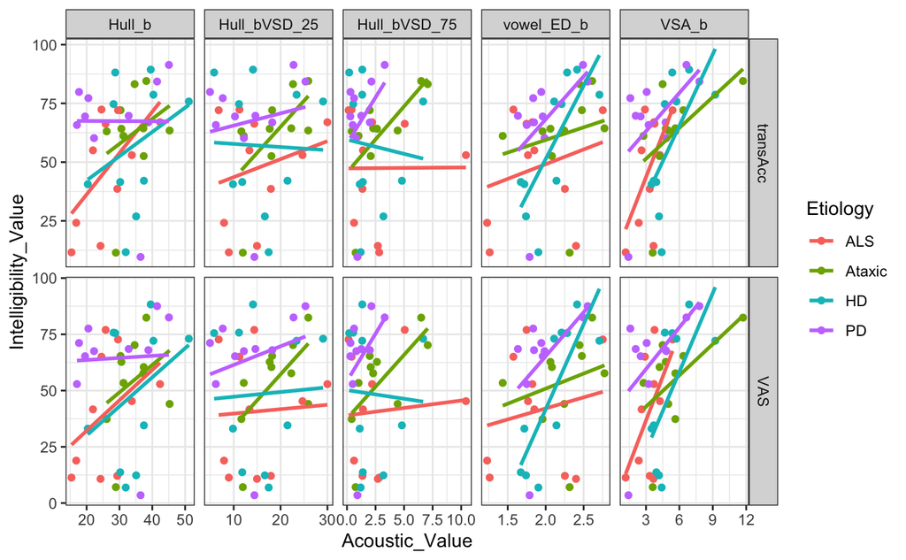

# Alternate Analysis

## Data Prep

```r
AcousticData <- AcousticData %>%
  dplyr::mutate(metaGroup = case_when(Etiology == "HD" ~ "A",
                                    Etiology == "Ataxic" ~ "A",
                                    TRUE ~ "B")) %>%
  dplyr::mutate(metaGroup = as.factor(metaGroup))
```

## Descriptives

```r
AcousticData %>%
  dplyr::group_by(metaGroup) %>%
  dplyr::summarize(VSA_mean = mean(VSA_b, na.rm =T), VSA_sd = sd(VSA_b, na.rm = T),
                   Disp_mean = mean(vowel_ED_b, na.rm =T), Disp_sd = sd(vowel_ED_b, na.rm =T),
                   Hull_mean = mean(Hull_b, na.rm =T), Hull_sd = sd(Hull_b, na.rm =T),
                   VSD25_mean = mean(Hull_bVSD_25, na.rm =T), VSD25_sd = sd(Hull_bVSD_25, na.rm =T),
                   VSD75_mean = mean(Hull_bVSD_75, na.rm =T), VSD75_sd = sd(Hull_bVSD_75, na.rm =T),
                   VAS_mean = mean(VAS, na.rm =T), VAS_sd = sd(VAS, na.rm =T),
                   OT_mean = mean(transAcc, na.rm =T), OT_sd = sd(transAcc, na.rm =T))
```

## Group Comparisons - 4 Groups

### VSA

```r
## Specify the Model
VSA_group <- aov(VSA_b ~ Etiology, data = AcousticData)

## Assumption Check

plot(VSA_group, 1)
plot(VSA_group, 2)
car::leveneTest(VSA_group)
VSA_residuals <- residuals(object = VSA_group)
shapiro.test(VSA_residuals)

## Model Results

summary(VSA_group)

## Kruskal-Wallis Test

kruskal.test(VSA_b ~ Etiology, data = AcousticData)

## Pairwise Comparisons

pairwise.wilcox.test(AcousticData$VSA_b, AcousticData$Etiology, p.adjust.method = "bonferroni")
```

### Corner Dispersion

```r
## Specify the Model
disp_group <- aov(vowel_ED_b ~ Etiology, data = AcousticData)

## Assumption Check

plot(disp_group, 1)
plot(disp_group, 2)
car::leveneTest(disp_group)
disp_residuals <- residuals(object = disp_group)
shapiro.test(disp_residuals)

## Model Results

summary(disp_group)
```

### Hull

```r
## Specify the Model
hull_group <- aov(Hull_b ~ Etiology, data = AcousticData)

## Assumption Check

plot(hull_group, 1)
plot(hull_group, 2)
car::leveneTest(hull_group)
hull_residuals <- residuals(object = hull_group)
shapiro.test(hull_residuals)

## Model Results

summary(hull_group)
```

### VSD 25

```r
## Specify the Model
vsd25_group <- aov(Hull_bVSD_25 ~ Etiology, data = AcousticData)

## Assumption Check

plot(vsd25_group, 1)
plot(vsd25_group, 2)
car::leveneTest(vsd25_group)
vsd25_residuals <- residuals(object = vsd25_group)
shapiro.test(vsd25_residuals)

## Model Summary

summary(vsd25_group)
```

### VSD 75

```r
## Specify the Model
vsd75_group <- aov(Hull_bVSD_75 ~ Etiology, data = AcousticData)

## Assumption Check

plot(vsd75_group, 1)
plot(vsd75_group, 2)
car::leveneTest(vsd75_group)
vsd75_residuals <- residuals(object = vsd75_group)
shapiro.test(vsd75_residuals)

## Model Summary

summary(vsd75_group)

## Kruskal Wallis

kruskal.test(Hull_bVSD_75 ~ Etiology, data = AcousticData)
```

## Group Comparisons - 2 Groups

This is the analysis for the two metagroups, Group A and B.

```r
groupA <- AcousticData %>%
  dplyr::filter(metaGroup == "A")

groupB <- AcousticData %>%
  dplyr::filter(metaGroup == "B")
```

### VSA

```r
# Assumption Check

## Checking Normality
with(AcousticData, shapiro.test(VSA_b[metaGroup == "A"]))
with(AcousticData, shapiro.test(VSA_b[metaGroup == "B"]))

## Equal Variance Check
res.ftest.VSA <- var.test(VSA_b ~ metaGroup, data = AcousticData)
res.ftest.VSA

# Model Results
VSA_b_t <- t.test(groupA$VSA_b, groupB$VSA_b, var.equal = T)
VSA_b_t
```

### Corner Dispersion

```r
# Assumption Check

## Checking Normality
with(AcousticData, shapiro.test(vowel_ED_b[metaGroup == "A"]))
with(AcousticData, shapiro.test(vowel_ED_b[metaGroup == "B"]))

## Equal Variance Check
res.ftest.disp <- var.test(vowel_ED_b ~ metaGroup, data = AcousticData)
res.ftest.disp

# Model Results
disp_t <- t.test(groupA$vowel_ED_b, groupB$vowel_ED_b, var.equal = T)
disp_t
```

### Hull

```r
# Assumption Check

## Checking Normality
with(AcousticData, shapiro.test(Hull_b[metaGroup == "A"]))
with(AcousticData, shapiro.test(Hull_b[metaGroup == "B"]))

## Equal Variance Check
res.ftest.hull <- var.test(Hull_b ~ metaGroup, data = AcousticData)
res.ftest.hull

# Model Results
hull_t <- t.test(groupA$Hull_b, groupB$Hull_b, var.equal = T)
hull_t
```

### VSD 25

```r
# Assumption Check

## Checking Normality
with(AcousticData, shapiro.test(Hull_bVSD_25[metaGroup == "A"]))
with(AcousticData, shapiro.test(Hull_bVSD_25[metaGroup == "B"]))

## Equal Variance Check
res.ftest.vsd25 <- var.test(Hull_bVSD_25 ~ metaGroup, data = AcousticData)
res.ftest.vsd25

# Model Results
vsd25_t <- t.test(groupA$Hull_bVSD_25, groupB$Hull_bVSD_25, var.equal = T)
vsd25_t
```

### VSD 75

```r
# Assumption Check

## Checking Normality
with(AcousticData, shapiro.test(Hull_bVSD_75[metaGroup == "A"]))
with(AcousticData, shapiro.test(Hull_bVSD_75[metaGroup == "B"]))

## Equal Variance Check
res.ftest.vsd75 <- var.test(Hull_bVSD_75 ~ metaGroup, data = AcousticData)
res.ftest.vsd75

# Model Results (Mann-Whitney U test conducted since assumption of normality is violated)
vsd75_MW <- wilcox.test(Hull_bVSD_75 ~ metaGroup, data = AcousticData)
vsd75_MW
```

### Intelligibility (OT)

```r
# Assumption Check

## Checking Normality
with(AcousticData, shapiro.test(transAcc[metaGroup == "A"]))
with(AcousticData, shapiro.test(transAcc[metaGroup == "B"]))

## Equal Variance Check
res.ftest.OT <- var.test(transAcc ~ metaGroup, data = AcousticData)
res.ftest.OT

# Model Results (Mann-Whitney U test conducted since assumption of normality is violated)
OT_MW <- wilcox.test(transAcc ~ metaGroup, data = AcousticData)
OT_MW
```

### Intelligibility (VAS)

```r
# Assumption Check

## Checking Normality
with(AcousticData, shapiro.test(VAS[metaGroup == "A"]))
with(AcousticData, shapiro.test(VAS[metaGroup == "B"]))

## Equal Variance Check
res.ftest.VAS <- var.test(VAS ~ metaGroup, data = AcousticData)
res.ftest.VAS

# Model Results (Mann-Whitney U test conducted since assumption of normality is violated)
OT_MW <- wilcox.test(VAS ~ metaGroup, data = AcousticData)
OT_MW
```

## OT Analysis

Since we found significant group differences for some acoustic measures between the ALS/PD and Ataxic/HD groups, we continued the heirarichal regression approach from OT Model 5. Adding in the Incoord predictor along with the interactions between the acoustic measures did not significantly improve model fit. So our original final OT model is retained.

### Model 6

```r
## Specifying Model 6
OT_Model6 <- lm(transAcc ~ Hull_bVSD_25 + Hull_bVSD_75 + Hull_b + VSA_b + vowel_ED_b + metaGroup, data = AcousticData)

## Model 6 Assumption Check
performance::check_model(OT_Model6)

## Model 6 Summary
summary(OT_Model6)

## Model 5 and Model 6 Comparison
anova(OT_Model5, OT_Model6)
```

### Model 7

```r
## Specifying Model 7
OT_Model7 <- lm(transAcc ~ Hull_bVSD_25 + Hull_bVSD_75 + Hull_b + VSA_b + vowel_ED_b +
                  metaGroup + metaGroup*Hull_bVSD_25, data = AcousticData)

## Model 7 Assumption Check
performance::check_model(OT_Model7)

## Model 7 Summary
summary(OT_Model7)

## Model 6 and Model 7 Comparison
anova(OT_Model6, OT_Model7)
```

### Model 8

```r
## Specifying Model 8
OT_Model8 <- lm(transAcc ~ Hull_bVSD_25 + Hull_bVSD_75 + Hull_b + VSA_b + vowel_ED_b +
                  metaGroup + metaGroup*Hull_bVSD_25 + metaGroup*Hull_bVSD_75, data = AcousticData)

## Model 8 Assumption Check
performance::check_model(OT_Model8)

## Model 8 Summary
summary(OT_Model8)

## Model 7 and Model 8 Comparison
anova(OT_Model7, OT_Model8)
```

### Model 9

```r
## Specifying Model 9
OT_Model9 <- lm(transAcc ~ Hull_bVSD_25 + Hull_bVSD_75 + Hull_b + VSA_b + vowel_ED_b + metaGroup +
                  metaGroup*Hull_bVSD_25 +
                  metaGroup*Hull_bVSD_75 +
                  metaGroup*Hull_b, data = AcousticData)

## Model 9 Assumption Check
performance::check_model(OT_Model9)

## Model 9 Summary
summary(OT_Model9)

## Model 8 and Model 9 Comparison
anova(OT_Model8, OT_Model9)
```

### Model 10

```r
## Specifying Model 10
OT_Model10 <- lm(transAcc ~ Hull_bVSD_25 + Hull_bVSD_75 + Hull_b + VSA_b + vowel_ED_b +
                   metaGroup +
                   metaGroup*Hull_bVSD_25 +
                   metaGroup*Hull_bVSD_75 +
                   metaGroup*Hull_b +
                   metaGroup*VSA_b,
                 data = AcousticData)

## Model 10 Assumption Check
performance::check_model(OT_Model10)

## Model 10 Summary
summary(OT_Model10)

## Model 9 and Model 10 Comparison
anova(OT_Model9, OT_Model10)
```

### Model 11

```r
## Specifying Model 11
OT_Model11 <- lm(transAcc ~ Hull_bVSD_25 + Hull_bVSD_75 + Hull_b + VSA_b + vowel_ED_b +
                   metaGroup +
                   metaGroup*Hull_bVSD_25 +
                   metaGroup*Hull_bVSD_75 +
                   metaGroup*Hull_b +
                   metaGroup*VSA_b +
                   metaGroup*vowel_ED_b,
                 data = AcousticData)

## Model 11 Assumption Check
performance::check_model(OT_Model11)

## Model 11 Summary
summary(OT_Model11)

## Model 10 and Model 11 Comparison
anova(OT_Model10, OT_Model11)
```

## VAS Analysis

Since we found significant group differences for some acoustic measures between the ALS/PD and Ataxic/HD groups, we continued the hierarchical regression approach from VAS Model 5. VAS Model 6 fit significantly better than VAS Model 5. However, adding in the interactions between Incoord and the acoustic measures did not significantly improve model fit.

### Model 6

```r
## Specifying Model 6
VAS_Model6 <- lm(VAS ~ Hull_bVSD_25 + Hull_bVSD_75 + Hull_b + VSA_b + vowel_ED_b +
                   metaGroup, data = AcousticData)

## Model 6 Assumption Check
performance::check_model(VAS_Model6)

## Model 6 Summary
summary(VAS_Model6)

## Model 5 and Model 6 Comparison
anova(VAS_Model5, VAS_Model6)
```

### Model 7

```r
## Specifying Model 7
VAS_Model7 <- lm(VAS ~ Hull_bVSD_25 + Hull_bVSD_75 + Hull_b + VSA_b + vowel_ED_b +
                  metaGroup + metaGroup*Hull_bVSD_25, data = AcousticData)

## Model 7 Assumption Check
performance::check_model(VAS_Model7)

## Model 7 Summary
summary(VAS_Model7)

## Model 6 and Model 7 Comparison
anova(VAS_Model6, VAS_Model7)
```

### Model 8

```r
## Specifying Model 8
VAS_Model8 <- lm(VAS ~ Hull_bVSD_25 + Hull_bVSD_75 + Hull_b + VSA_b + vowel_ED_b +
                  metaGroup + metaGroup*Hull_bVSD_25 + metaGroup*Hull_bVSD_75, data = AcousticData)

## Model 8 Assumption Check
performance::check_model(VAS_Model8)

## Model 8 Summary
summary(VAS_Model8)

## Model 7 and Model 8 Comparison
anova(VAS_Model7, VAS_Model8)
```

### Model 9

```r
## Specifying Model 9
VAS_Model9 <- lm(VAS ~ Hull_bVSD_25 + Hull_bVSD_75 + Hull_b + VSA_b + vowel_ED_b +
                   metaGroup +
                   metaGroup*Hull_bVSD_25 +
                   metaGroup*Hull_bVSD_75 +
                   metaGroup*Hull_b,
                 data = AcousticData)

## Model 9 Assumption Check
performance::check_model(VAS_Model9)

## Model 9 Summary
summary(VAS_Model9)

## Model 8 and Model 9 Comparison
anova(VAS_Model8, VAS_Model9)
```

### Model 10

```r
## Specifying Model 10
VAS_Model10 <- lm(VAS ~ Hull_bVSD_25 + Hull_bVSD_75 + Hull_b + VSA_b + vowel_ED_b +
                    metaGroup +
                    metaGroup*Hull_bVSD_25 +
                    metaGroup*Hull_bVSD_75 +
                    metaGroup*Hull_b +
                    metaGroup*VSA_b,
                  data = AcousticData)

## Model 10 Assumption Check
performance::check_model(VAS_Model10)

## Model 10 Summary
summary(VAS_Model10)

## Model 9 and Model 10 Comparison
anova(VAS_Model9, VAS_Model10)
```

### Model 11

```r
## Specifying Model 11
VAS_Model11 <- lm(VAS ~ Hull_bVSD_25 + Hull_bVSD_75 + Hull_b + VSA_b + vowel_ED_b +
                    metaGroup +
                    metaGroup*Hull_bVSD_25 +
                    metaGroup*Hull_bVSD_75 +
                    metaGroup*Hull_b +
                    metaGroup*VSA_b +
                    metaGroup*vowel_ED_b,
                  data = AcousticData)

## Model 11 Assumption Check
performance::check_model(VAS_Model11)

## Model 11 Summary
summary(VAS_Model11)

## Model 10 and Model 11 Comparison
anova(VAS_Model10, VAS_Model11)
```

### New Final VAS Model

Since VAS Model 6 was significantly better fit than Model 5, we fit a new final parsimonious model for VAS to the data (VAS ~ VSA_b + metaGroup) and compared that to the old final VAS model (VAS ~ VSA_b). The new final model was not a significantly better fit than the old final model. Thus the old final model (VAS ~ VSA_b) is retained.

```r
## Specifying New Final VAS Model
VAS_Model_newfinal <- lm(VAS ~ VSA_b + metaGroup, data = AcousticData)

## New Final VAS Model Assumption Check
performance::check_model(VAS_Model_newfinal)

## New Final VAS Model Summary
summary(VAS_Model_newfinal)

## Comparison to Old Final Model
anova(VAS_Model_final, VAS_Model_newfinal)
```

## Testing Individual Predictors

Because some correlations between predictors are high. We run a series of simple linear regressions to test if the predictors significantly predict each intelligibility measure on their own (VSD 25 and VSA models were already complete in our initial model comparison approach)

### Orthographic Transcription Models

```r
# OT ~ VSD 75
OT_vsd75_model <- lm(transAcc ~ Hull_bVSD_75, data = AcousticData)
performance::check_model(OT_vsd75_model)
summary(OT_vsd75_model)

# OT ~ Hull
OT_hull_model <- lm(transAcc ~ Hull_b, data = AcousticData)
performance::check_model(OT_hull_model)
summary(OT_hull_model)

# OT ~ Corner Dispersion
OT_disp_model <- lm(transAcc ~ vowel_ED_b, data = AcousticData)
performance::check_model(OT_disp_model)
summary(OT_disp_model)
```

### VAS Models

```r
# VAS ~ VSD 75
VAS_vsd75_model <- lm(VAS ~ Hull_bVSD_75, data = AcousticData)
performance::check_model(VAS_vsd75_model)
summary(VAS_vsd75_model)

# VAS ~ Hull
VAS_hull_model <- lm(VAS ~ Hull_b, data = AcousticData)
performance::check_model(VAS_hull_model)
summary(VAS_hull_model)

# VAS ~ Corner Dispersion
VAS_disp_model <- lm(VAS ~ vowel_ED_b, data = AcousticData)
performance::check_model(VAS_disp_model)
summary(VAS_disp_model)
```